# Tidy Data

July 2019

## GAISE 2016

### [Guidelines for Assessment and Instruction in Statistics Education](https://www.amstat.org/asa/education/Guidelines-for-Assessment-and-Instruction-in-Statistics-Education-Reports.aspx)

1. Teach statistical thinking.
   - Teach statistics as an **investigative process** of problem-solving and **decision-making**.
   - Give students experience with **multivariable thinking**.
2. Focus on conceptual understanding.
3. Integrate **real data** with a **context** and **purpose**.
4. Foster **active learning**.
5. Use **technology** to explore concepts and analyze data.
6. Use **assessments** to improve and evaluate student learning.

## Real data a la StatPREP

*See [StatPREP newsletter](http://statprep.org/wp-content/uploads/2019/02/Spring-Newsletter-02.11.19.pdf) for lengthier discussion*

- **captured in the wild**: not collected for teaching statistics
- **appropriate for investigation** of a particular question or set of questions
- **large** enough (think: \(n \ge 1000\))
- **rich** enough (think: 5 or more variables)

Working with this sort of data can hone good data skills

- requires organization and automation
- encourages multivariable thinking
- good tools will scale to much larger, richer data sets

These same skills will work for simpler data sets as well, of course.

## Data organization

- Organizing data properly is critically important for …
  - **thinking** correctly with data
  - using real data with **technology**
- Textbooks often do bad things with data
  - optimized for printing on a page
  - trains people to think about data in bad ways
- Excel users often abuse Excel’s flexibility
  - optimized for “seeing” the data and for manual entry
  - makes data hard to work with for analysis
  - trains people to think about data in bad ways

## Unruly data

**unruly**: (adj.) disorderly and disruptive and not amenable to discipline or control

### Some Examples

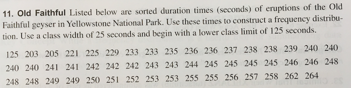

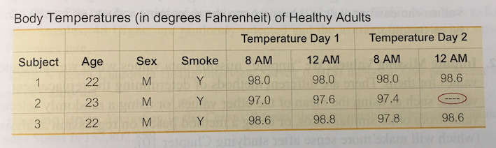

## Rules tame unruliness

1. Always in a “**spreadsheet**” (ie, rows and columns) *fail* ︎
2. **Rows**: One row per unit of observation/analysis
   - No summaries in data︎
   - No other info, e.g. codebook, in spreadsheet *fail*
   - Any subset of rows is a valid data set.
3. **Columns**: One column per variable *fail*
   - Always use column names *fail*
4. Always codebook *fail*
   - Rows: how cases were selected
   - Columns: units, specific questions/protocols/methods
5. Segregate data collection and data analysis
   - Never change the original data as part of the analysis

*Note: This sort of tidy/rectangular data is not the only kind of data, but it is an extremely important kind of data and sufficient for introductory courses.*

## Operations on Tidy Data

Advantage of tidy data: it is ammenable to **standard, reusable data operations**.

## Operations on Tidy Data

Advantage of tidy data: it is ammenable to **standard, reusable data operations**.

### Fundamental Operations

- **summarize** / **reduce**: convert entire data set to 1-row of summary values
  - in spreadsheet: often not tidy, summary formulas can be placed in untidy places
  - in R: `summarise()`; `df_stats()`, etc.
- **mutate** / **transform**: add new variable
  - in spreadsheet: add a new column
  - in R: `mutate()`
- **filter**: remove/ignore rows or columns
  - in spreadsheet: [“hide” data](https://support.google.com/docs/answer/3540681)
  - in R: `filter()`

## Operations on Tidy Data

Advantage of tidy data: it is ammenable to **standard, reusable data operations**.

### Superficial Operations

- **select**: remove/ignore columns
  - in spreadsheet: [“hide” data](https://support.google.com/docs/answer/3540681)
  - in R: `select()`
- **arrange**
  - in spreadsheet, “sort”. But how do you do this without altering the data?
  - in R: `arrange()`

## Operations on Tidy Data

Advantage of tidy data: it is ammenable to **standard, reusable data operations**.

### Profound Operations

- **group**: handle summarize and mutate in a groupwise way
  - in spreadsheet: [pivot table](https://support.google.com/docs/answer/1272900)
  - in R: `group_by()`; formulas (eg, `blood_pressure ~ age + sex`)
- **join**: bring together data from multiple sources
  - in spreadsheet [“fusion tables”](https://support.google.com/fusiontables/answer/171254?hl=en) but will be [phased out in Dec. 2019 in terms of SQL operations](https://support.google.com/fusiontables/answer/9185417)
- **spread** / **gather**: change unit of analysis
  - in spreadsheet [pivot/unpivot](https://eagereyes.org/basics/spreadsheet-thinking-vs-database-thinking)
  - in R: `pivot_wider()`, `pivot_longer()` [formerly `spread()`, `gather()`]

## Shape: Long vs Wide Data

Need to be able to move between these two formats.

**Long**

| country | continent | year | lifeExp |
| --- | --- | --- | --- |
| Afghanistan | Asia | 1952 | 28.801 |
| Afghanistan | Asia | 1957 | 30.332 |
| Afghanistan | Asia | 1962 | 31.997 |
| Afghanistan | Asia | 1967 | 34.020 |
| Afghanistan | Asia | 1972 | 36.088 |
| Afghanistan | Asia | 1977 | 38.438 |

**Wide**

[output not shown]

## Quiz

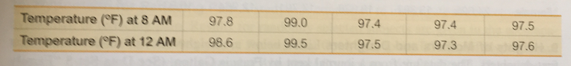

List the many ways in which this “table” violates the conventions for effective data organization.

## Taxonomy of Variable Types

1. Numerical
   - **quantities** (with **dimension** and **units**) –
   - **times** and **dates**
   - **counts** (natural numbers)
   - codes represent discrete levels, not really numerical
2. Categorical
   - Note: “Two-sample” isn’t (usually) two samples
     - one sample, two **variables**
     - categorical variable identifies the group
   - Summarizing with proportions doesn’t make categrical data numerical
   - Can be ordered or unordered

## Taxonomy of Variable Roles

1. Explanatory
   - a.k.a predictor, regressor, input, feature, independent
2. Response
   - a.k.a. predicted, dependent

**Key question:** How does the response depend on the explanatory variable(s)?